# Estimating Prediabetes Prevalence in the Faroe Islands

Inverse Probability Weighting and Age-Sex Standardisation

Author

Faroe Islands Prediabetes Study

Published

March 24, 2026

```r
library(tidyverse)
library(pxweb)
library(gt)
library(scales)
library(wesanderson)
```

## Background

We have access to every HbA1c measurement taken in the Faroese population. We want to estimate the **prevalence of prediabetes** (HbA1c 42–47 mmol/mol) among people aged 30–79. A person is classified as having prediabetes if they:

1. Had an HbA1c measurement in the last 24 months,
2. Their most recent measurement was 42–47 mmol/mol, and
3. They have never had an HbA1c ≥ 48 or a T1D/T2D diagnosis.

The goal is to estimate the **true population prevalence** of prediabetes using the supervisor’s recommended approach:

1. **Inverse Probability Weighting (IPW)**: account for the selective nature of testing by upweighting under-represented individuals.
2. **Direct age-sex standardisation**: combine group-specific estimates using the actual population age-sex distribution from Hagstova Føroya.

## 1. Population Data from Hagstova Føroya

We retrieve the number of people in each 5-year age group (30–79) by sex from the Faroese Statistics Bureau — [Hagstova Føroya](https://statbank.hagstova.fo/PXWeb/pxweb/en/H2/H2__BI__BI01/). The data are available via their PX-Web statistics bank (table **BI0101**, *Population by sex and age*).

```r
# ── Try to download from Hagstova Føroya PX-Web API ───────────────────────────
# Table BI0101: Population by sex (Kyn) and single-year age (Aldur).
# To explore the database interactively in an R session, run:
#   pxweb::pxweb_interactive("https://statbank.hagstova.fo/PXWeb/api/v1/en/")
#
# Variable codes used below (Faroese):
#   Ár    = Year          (we take the most recent)
#   Kyn   = Sex           M = Male, K = Female (kona)
#   Aldur = Age (integer) ages 30–79
#
# The API URL follows the PX-Web v1 standard:
#   https://statbank.hagstova.fo/PXWeb/api/v1/en/H2/H2__BI__BI01/BI0101.px

fetch_hagstova <- function() {
  url <- paste0(
    "https://statbank.hagstova.fo/PXWeb/api/v1/en/",
    "H2/H2__BI__BI01/BI0101.px"
  )
  # pxweb_get() accepts a named list of character vectors; use "*" to select
  # all values of a variable and then subset afterwards.
  query <- list(
    "\u00c1r"  = c("*"),                          # all years; we keep the latest
    "Kyn"      = c("M", "K"),                     # M = Male, K = Female (kona)
    "Aldur"    = as.character(30:79)               # single-year ages 30–79
  )
  tryCatch({
    raw <- pxweb_get(url = url, query = query)
    as.data.frame(raw, column.name.type = "text", variable.value.type = "text")
  }, error = function(e) {
    message(
      "Could not download from Hagstova Føroya (", conditionMessage(e), ").\n",
      "Using hardcoded 2024 population counts from the same source.\n",
      "Manual download: https://statbank.hagstova.fo/PXWeb/pxweb/en/H2/H2__BI__BI01/"
    )
    NULL
  })
}

# ── Helper: keep only the most recent year and collapse to 5-year groups ──────
to_5yr_groups <- function(df) {
  names(df) <- tolower(trimws(names(df)))

  # Identify the population count column (last numeric-ish column)
  count_col <- tail(names(df), 1)

  # Rename Faroese variable names to English if present
  if ("\u00e1r" %in% names(df))    df <- rename(df, year  = "\u00e1r")
  if ("kyn"    %in% names(df))    df <- rename(df, sex   = kyn)
  if ("aldur"  %in% names(df))    df <- rename(df, age   = aldur)

  df |>
    mutate(
      year    = as.integer(gsub("\\D", "", year)),
      age_num = as.integer(gsub("\\D", "", age)),
      n       = as.numeric(.data[[count_col]])
    ) |>
    filter(year == max(year, na.rm = TRUE)) |>       # keep most recent year only
    mutate(
      age_group = paste0(floor((age_num - 30) / 5) * 5 + 30, "-",
                         floor((age_num - 30) / 5) * 5 + 34),
      sex = case_match(sex,
                       c("M", "Males", "Male", "1") ~ "Male",
                       .default = "Female")
    ) |>
    group_by(age_group, sex) |>
    summarise(N = sum(n, na.rm = TRUE), .groups = "drop")
}

# ── Hardcoded fallback: Hagstova Føroya, table BI0101, January 2024 ──────────
# Source: https://statbank.hagstova.fo/PXWeb/pxweb/en/H2/H2__BI__BI01/
hardcoded_pop <- tribble(
  ~age_group, ~sex,       ~N,
  "30-34",    "Male",   1788,
  "30-34",    "Female", 1651,
  "35-39",    "Male",   2047,
  "35-39",    "Female", 1800,
  "40-44",    "Male",   1774,
  "40-44",    "Female", 1531,
  "45-49",    "Male",   1779,
  "45-49",    "Female", 1558,
  "50-54",    "Male",   1824,
  "50-54",    "Female", 1542,
  "55-59",    "Male",   1802,
  "55-59",    "Female", 1636,
  "60-64",    "Male",   1686,
  "60-64",    "Female", 1568,
  "65-69",    "Male",   1435,
  "65-69",    "Female", 1452,
  "70-74",    "Male",    1285,
  "70-74",    "Female",  1244,
  "75-79",    "Male",    1087,
  "75-79",    "Female",  1091
)

# Ordered factor levels for consistent display
age_lvls <- c("30-34","35-39","40-44","45-49","50-54",
              "55-59","60-64","65-69","70-74","75-79")
age_mids <- setNames(c(32, 37, 42, 47, 52, 57, 62, 67, 72, 77), age_lvls)

raw_dl <- fetch_hagstova()

pop_data <- (if (!is.null(raw_dl)) to_5yr_groups(raw_dl) else hardcoded_pop) |>
  mutate(
    age_group = factor(age_group, levels = age_lvls),
    age_mid   = age_mids[as.character(age_group)]
  )

N_total <- sum(pop_data$N)
```

```r
pop_wide <- pop_data |>
  arrange(age_group, sex) |>
  select(age_group, sex, N) |>
  pivot_wider(names_from = sex, values_from = N) |>
  mutate(Total = Male + Female)

# Append a grand-total row manually for maximum gt-version compatibility
pop_total_row <- tibble(
  age_group = factor("Total", levels = c(age_lvls, "Total")),
  Male      = sum(pop_wide$Male),
  Female    = sum(pop_wide$Female),
  Total     = sum(pop_wide$Total)
)

bind_rows(pop_wide, pop_total_row) |>
  gt() |>
  tab_header(
    title    = "Faroese population aged 30–79, by 5-year age group and sex",
    subtitle = "Source: Hagstova Føroya (Statistics Faroe Islands) – table BI0101, 2024"
  ) |>
  cols_label(age_group = "Age group") |>
  fmt_number(columns = c(Male, Female, Total), decimals = 0) |>
  tab_style(
    style     = list(cell_text(weight = "bold"), cell_fill(color = "#f0f0f0")),
    locations = cells_body(rows = age_group == "Total")
  )
```

Faroese population aged 30–79, by 5-year age group and sex

Source: Hagstova Føroya (Statistics Faroe Islands) – table BI0101, 2024

| Age group | Female | Male | Total |
| --- | --- | --- | --- |
| 30-34 | 1,651 | 1,788 | 3,439 |
| 35-39 | 1,800 | 2,047 | 3,847 |
| 40-44 | 1,531 | 1,774 | 3,305 |
| 45-49 | 1,558 | 1,779 | 3,337 |
| 50-54 | 1,542 | 1,824 | 3,366 |
| 55-59 | 1,636 | 1,802 | 3,438 |
| 60-64 | 1,568 | 1,686 | 3,254 |
| 65-69 | 1,452 | 1,435 | 2,887 |
| 70-74 | 1,244 | 1,285 | 2,529 |
| 75-79 | 1,091 | 1,087 | 2,178 |
| Total | 15,073 | 16,507 | 31,580 |

## 2. Data Simulation

We simulate an individual-level dataset for the entire Faroese population aged 30–79. Each person’s characteristics are drawn independently:

| Variable | How it is generated |
| --- | --- |
| **Diabetes** (T1D/T2D) | Bernoulli with age-specific probability (5–20 %) |
| **Prediabetes** | Bernoulli (only for non-diabetics); peaks in middle age |
| **Tested** | Bernoulli with `P = 1` if diabetic; otherwise logistic function of age and sex, calibrated so overall non-diabetic testing rate ≈ 40 % and males/older people are more likely to be tested |

### 2.1 Simulation parameters

```r
set.seed(42)

# True diabetes prevalence by age group
p_dm_by_age <- c(
  "30-34" = 0.05, "35-39" = 0.06, "40-44" = 0.07, "45-49" = 0.09,
  "50-54" = 0.11, "55-59" = 0.14, "60-64" = 0.17, "65-69" = 0.19,
  "70-74" = 0.20, "75-79" = 0.20
)

# True prediabetes prevalence among non-diabetics, by age group
p_pre_by_age <- c(
  "30-34" = 0.10, "35-39" = 0.13, "40-44" = 0.16, "45-49" = 0.19,
  "50-54" = 0.22, "55-59" = 0.23, "60-64" = 0.22, "65-69" = 0.20,
  "70-74" = 0.18, "75-79" = 0.15
)

# Logistic model for P(tested | non-diabetic, age_mid, sex)
# logit(p) = alpha + beta_age * (age_mid - 55) / 10 + beta_sex * I(Male)
# Calibrated so overall non-diabetic testing rate ≈ 40 %
alpha_t    <- -0.55   # female, age 55 → plogis(-0.55) ≈ 0.37
beta_age_t <-  0.40   # +0.40 log-OR per 10-year increase
beta_sex_t <-  0.50   # +0.50 log-OR for males vs females

p_test_nondm <- function(age_mid, sex) {
  plogis(alpha_t + beta_age_t * (age_mid - 55) / 10 +
           beta_sex_t * (sex == "Male"))
}
```

### 2.2 Simulate individuals

```r
sim_pop <- pmap_dfr(pop_data, function(age_group, sex, N, age_mid) {
  ag  <- as.character(age_group)
  dm  <- rbinom(N, 1, p_dm_by_age[ag])
  pre <- rbinom(N, 1, p_pre_by_age[ag])  # potential prediabetes draw

  tibble(
    age_group = ag,
    sex       = sex,
    age_mid   = age_mid,
    diabetes  = dm,
    # A diabetic person cannot be prediabetic by our definition
    pre_true  = if_else(dm == 1L, 0L, pre),
    # P(tested) = 1 for diabetics, logistic model for non-diabetics
    p_test    = if_else(dm == 1L, 1, p_test_nondm(age_mid, sex)),
    tested    = rbinom(N, 1, p_test),
    # We only observe prediabetes / diabetes for tested individuals
    pre_obs   = if_else(tested == 1L, pre_true, NA_integer_),
    dm_obs    = if_else(tested == 1L, dm,       NA_integer_)
  )
}) |>
  mutate(age_group = factor(age_group, levels = age_lvls))

# ── Quick sanity checks ───────────────────────────────────────────────────────
cat(sprintf(
  "Total simulated:                %6d\n",         nrow(sim_pop)
))
```

```
Total simulated:                 31580
```

```r
cat(sprintf(
  "Tested:                         %6d  (%4.1f %%)\n",
  sum(sim_pop$tested), 100 * mean(sim_pop$tested)
))
```

```
Tested:                          15288  (48.4 %)
```

```r
cat(sprintf(
  "Non-diabetic testing rate:      %6.1f %%\n",
  100 * mean(sim_pop$tested[sim_pop$diabetes == 0])
))
```

```
Non-diabetic testing rate:        41.0 %
```

```r
cat(sprintf(
  "Diabetes prevalence (true):     %6.1f %%\n",
  100 * mean(sim_pop$diabetes)
))
```

```
Diabetes prevalence (true):       12.5 %
```

```r
cat(sprintf(
  "Prediabetes prevalence (true):  %6.1f %%\n",
  100 * mean(sim_pop$pre_true)
))
```

```
Prediabetes prevalence (true):    15.6 %
```

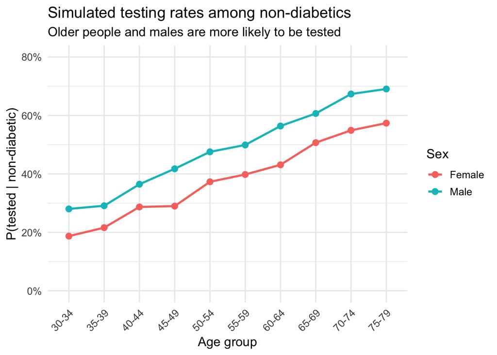

```r
sim_pop |>
  filter(diabetes == 0) |>
  group_by(age_group, sex) |>
  summarise(p_tested = mean(tested), .groups = "drop") |>
  ggplot(aes(x = age_group, y = p_tested, colour = sex, group = sex)) +
  geom_line(linewidth = 1) +
  geom_point(size = 2.5) +
  scale_y_continuous(labels = percent_format(accuracy = 1), limits = c(0, 0.8)) +
  labs(
    title    = "Simulated testing rates among non-diabetics",
    subtitle = "Older people and males are more likely to be tested",
    x = "Age group", y = "P(tested | non-diabetic)", colour = "Sex"
  ) +
  theme_minimal(base_size = 13) +
  theme(axis.text.x = element_text(angle = 45, hjust = 1))
```

## 3. Estimating Prediabetes Prevalence

We use three approaches, ranging from simplest to most rigorous.

### 3.1 Naive estimates (for comparison)

```r
tested_sample <- sim_pop |> filter(tested == 1L)

naive_over_tested <- mean(tested_sample$pre_obs, na.rm = TRUE)
naive_over_pop    <- sum(tested_sample$pre_obs,  na.rm = TRUE) / N_total

tibble(
  Method   = c("Tested with prediabetes ÷ total tested",
               "Tested with prediabetes ÷ full population"),
  Estimate = c(naive_over_tested, naive_over_pop)
) |>
  gt() |>
  fmt_percent(columns = Estimate, decimals = 2) |>
  tab_header(
    title    = "Naive prediabetes prevalence estimates",
    subtitle = "Both are biased: the first ignores under-testing; the second ignores untested prediabetics"
  )
```

Naive prediabetes prevalence estimates

Both are biased: the first ignores under-testing; the second ignores untested prediabetics

| Method | Estimate |
| --- | --- |
| Tested with prediabetes ÷ total tested | 13.85% |
| Tested with prediabetes ÷ full population | 6.71% |

### 3.2 IPW + Direct Standardisation

#### Step 1 — Testing probability per age-sex group

For each group $g$ (a combination of age band and sex) we estimate the probability of testing as

$$\hat{p}_g = \frac{n_g^{\text{tested}}}{N_g}$$

where $N_g$ is from Hagstova and $n_g^{\text{tested}}$ comes from our dataset.

> **Refinement (optional):** Because every diabetic is presumed to be tested, the non-diabetic-specific testing probability is
> $$\hat{p}_g^{\,\text{non-DM}} = \frac{n_g^{\text{tested}} - n_g^{\text{DM}}}{N_g - n_g^{\text{DM}}}$$
> In practice the two estimates are very close when diabetes prevalence is low. We compute both below.

```r
group_stats <- sim_pop |>
  filter(tested == 1L) |>
  group_by(age_group, sex) |>
  summarise(
    n_tested = n(),
    n_dm     = sum(dm_obs,  na.rm = TRUE),
    n_pre    = sum(pre_obs, na.rm = TRUE),
    .groups  = "drop"
  ) |>
  left_join(pop_data |> select(age_group, sex, N), by = c("age_group", "sex")) |>
  mutate(
    p_hat_marg  = n_tested / N,                           # marginal
    p_hat_nondm = (n_tested - n_dm) / (N - n_dm),        # conditional on non-DM
    # Within-group IPW prevalence (marginal weights) = naive within-group rate:
    #   π̂_g = (1/N_g) Σ_{tested} (1/p̂_g) 1[pre_i]
    #        = (N_g / n_tested) * n_pre / N_g = n_pre / n_tested
    prev_g_marg = n_pre / n_tested,
    # Within-group IPW prevalence (non-DM-corrected weights):
    #   π̂_g = (1/N_g) Σ_{tested non-DM} (1/p̂_nondm) 1[pre_i]
    #        = (1/N_g) * n_pre / p̂_nondm
    # This gives the prevalence *out of the total group* (incl. diabetics),
    # which is what we need when standardising with weights N_g / N_total.
    prev_g_nondm = (n_pre / p_hat_nondm) / N
  )

group_stats |>
  select(age_group, sex, N, n_tested, p_hat_marg, p_hat_nondm) |>
  gt() |>
  cols_label(
    age_group   = "Age group",
    N           = "Population",
    n_tested    = "N tested",
    p_hat_marg  = "p̂ (marginal)",
    p_hat_nondm = "p̂ (non-DM)"
  ) |>
  fmt_number(columns = N, decimals = 0) |>
  fmt_percent(columns = c(p_hat_marg, p_hat_nondm), decimals = 1) |>
  tab_header("Estimated testing probabilities by age-sex group")
```

Estimated testing probabilities by age-sex group

| Age group | sex | Population | N tested | p̂ (marginal) | p̂ (non-DM) |
| --- | --- | --- | --- | --- | --- |
| 30-34 | Female | 1,651 | 379 | 23.0% | 18.7% |
| 30-34 | Male | 1,788 | 558 | 31.2% | 28.0% |
| 35-39 | Female | 1,800 | 476 | 26.4% | 21.6% |
| 35-39 | Male | 2,047 | 678 | 33.1% | 29.1% |
| 40-44 | Female | 1,531 | 515 | 33.6% | 28.7% |
| 40-44 | Male | 1,774 | 725 | 40.9% | 36.5% |
| 45-49 | Female | 1,558 | 568 | 36.5% | 29.0% |
| 45-49 | Male | 1,779 | 833 | 46.8% | 41.7% |
| 50-54 | Female | 1,542 | 690 | 44.7% | 37.3% |
| 50-54 | Male | 1,824 | 968 | 53.1% | 47.5% |
| 55-59 | Female | 1,636 | 795 | 48.6% | 39.8% |
| 55-59 | Male | 1,802 | 1032 | 57.3% | 49.9% |
| 60-64 | Female | 1,568 | 829 | 52.9% | 43.1% |
| 60-64 | Male | 1,686 | 1071 | 63.5% | 56.4% |
| 65-69 | Female | 1,452 | 884 | 60.9% | 50.7% |
| 65-69 | Male | 1,435 | 980 | 68.3% | 60.7% |
| 70-74 | Female | 1,244 | 811 | 65.2% | 54.9% |
| 70-74 | Male | 1,285 | 959 | 74.6% | 67.3% |
| 75-79 | Female | 1,091 | 718 | 65.8% | 57.4% |
| 75-79 | Male | 1,087 | 819 | 75.3% | 69.1% |

#### Step 2 — Within-group prediabetes prevalence (= IPW within each group)

The IPW estimator of prediabetes prevalence **within** group $g$ is:

$$\hat{\pi}_g^{\,\text{IPW}} = \frac{\displaystyle\sum_{i \in g,\,\text{tested}} \frac{1}{\hat{p}_g}\,\mathbf{1}[\text{pre}_i]}{\displaystyle\sum_{i \in g,\,\text{tested}} \frac{1}{\hat{p}_g}}$$

Using the **marginal** testing probability $\hat{p}_g = n_g^{\text{tested}}/N_g$, the $1/\hat{p}_g$ factors cancel:

$$\hat{\pi}_g^{\,\text{IPW, marg}} = \frac{n_g^{\text{pre}}}{n_g^{\text{tested}}}$$

This is simply the **naive within-group proportion**. The IPW weights do *not* change the within-group estimate when testing probability is uniform within the group — their role is to determine how groups should be aggregated.

Using the **non-DM-corrected** probability, the denominator shifts to $N_g - n_g^{\text{DM}}$, giving a slightly different within-group estimate.

```r
group_stats |>
  select(age_group, sex, n_pre, n_tested, n_dm, prev_g_marg, prev_g_nondm) |>
  gt() |>
  cols_label(
    age_group    = "Age group",
    n_pre        = "Prediabetes (tested)",
    n_tested     = "N tested",
    n_dm         = "N diabetic (tested)",
    prev_g_marg  = "IPW prev (marginal)",
    prev_g_nondm = "IPW prev (non-DM)"
  ) |>
  fmt_percent(columns = c(prev_g_marg, prev_g_nondm), decimals = 1) |>
  tab_header("Within-group prediabetes prevalence from the two IPW approaches")
```

Within-group prediabetes prevalence from the two IPW approaches

| Age group | sex | Prediabetes (tested) | N tested | N diabetic (tested) | IPW prev (marginal) | IPW prev (non-DM) |
| --- | --- | --- | --- | --- | --- | --- |
| 30-34 | Female | 27 | 379 | 86 | 7.1% | 8.7% |
| 30-34 | Male | 51 | 558 | 79 | 9.1% | 10.2% |
| 35-39 | Female | 43 | 476 | 111 | 9.0% | 11.1% |
| 35-39 | Male | 84 | 678 | 116 | 12.4% | 14.1% |
| 40-44 | Female | 66 | 515 | 106 | 12.8% | 15.0% |
| 40-44 | Male | 106 | 725 | 123 | 14.6% | 16.4% |
| 45-49 | Female | 83 | 568 | 164 | 14.6% | 18.4% |
| 45-49 | Male | 136 | 833 | 155 | 16.3% | 18.3% |
| 50-54 | Female | 118 | 690 | 183 | 17.1% | 20.5% |
| 50-54 | Male | 179 | 968 | 192 | 18.5% | 20.6% |
| 55-59 | Female | 127 | 795 | 239 | 16.0% | 19.5% |
| 55-59 | Male | 182 | 1032 | 265 | 17.6% | 20.2% |
| 60-64 | Female | 126 | 829 | 269 | 15.2% | 18.6% |
| 60-64 | Male | 163 | 1071 | 276 | 15.2% | 17.1% |
| 65-69 | Female | 115 | 884 | 300 | 13.0% | 15.6% |
| 65-69 | Male | 145 | 980 | 278 | 14.8% | 16.7% |
| 70-74 | Female | 79 | 811 | 284 | 9.7% | 11.6% |
| 70-74 | Male | 121 | 959 | 287 | 12.6% | 14.0% |
| 75-79 | Female | 74 | 718 | 216 | 10.3% | 11.8% |
| 75-79 | Male | 93 | 819 | 221 | 11.4% | 12.4% |